# Risk Factor Analysis

## Outcome Variable

**Outcome Variable:** haz

## Predictor Variables

**Intervention Variable:** perdiar24

**Adjustment Set:**

unadjusted

## Stratifying Variables

The analysis was stratified on these variable(s):

- agecat
- studyid
- country

## Data Summary

| agecat | studyid | country | perdiar24 | n_cell | n |
| --- | --- | --- | --- | --- | --- |
| Birth | ki0047075b-MAL-ED | BANGLADESH | 0% | 22 | 257 |
| Birth | ki0047075b-MAL-ED | BANGLADESH | (0%, 5%] | 146 | 257 |
| Birth | ki0047075b-MAL-ED | BANGLADESH | >5% | 89 | 257 |
| Birth | ki0047075b-MAL-ED | BRAZIL | 0% | 108 | 191 |
| Birth | ki0047075b-MAL-ED | BRAZIL | (0%, 5%] | 81 | 191 |
| Birth | ki0047075b-MAL-ED | BRAZIL | >5% | 2 | 191 |
| Birth | ki0047075b-MAL-ED | INDIA | 0% | 12 | 206 |
| Birth | ki0047075b-MAL-ED | INDIA | (0%, 5%] | 156 | 206 |
| Birth | ki0047075b-MAL-ED | INDIA | >5% | 38 | 206 |
| Birth | ki0047075b-MAL-ED | NEPAL | 0% | 14 | 173 |
| Birth | ki0047075b-MAL-ED | NEPAL | (0%, 5%] | 103 | 173 |
| Birth | ki0047075b-MAL-ED | NEPAL | >5% | 56 | 173 |
| Birth | ki0047075b-MAL-ED | PERU | 0% | 27 | 287 |
| Birth | ki0047075b-MAL-ED | PERU | (0%, 5%] | 109 | 287 |
| Birth | ki0047075b-MAL-ED | PERU | >5% | 151 | 287 |
| Birth | ki0047075b-MAL-ED | SOUTH AFRICA | 0% | 95 | 252 |
| Birth | ki0047075b-MAL-ED | SOUTH AFRICA | (0%, 5%] | 154 | 252 |
| Birth | ki0047075b-MAL-ED | SOUTH AFRICA | >5% | 3 | 252 |
| Birth | ki0047075b-MAL-ED | TANZANIA, UNITED REPUBLIC OF | 0% | 8 | 123 |
| Birth | ki0047075b-MAL-ED | TANZANIA, UNITED REPUBLIC OF | (0%, 5%] | 90 | 123 |
| Birth | ki0047075b-MAL-ED | TANZANIA, UNITED REPUBLIC OF | >5% | 25 | 123 |
| Birth | ki1000109-EE | PAKISTAN | 0% | 0 | 2 |
| Birth | ki1000109-EE | PAKISTAN | (0%, 5%] | 2 | 2 |
| Birth | ki1000109-EE | PAKISTAN | >5% | 0 | 2 |
| Birth | ki1000109-ResPak | PAKISTAN | 0% | 0 | 6 |
| Birth | ki1000109-ResPak | PAKISTAN | (0%, 5%] | 2 | 6 |
| Birth | ki1000109-ResPak | PAKISTAN | >5% | 4 | 6 |
| Birth | ki1017093-NIH-Birth | BANGLADESH | 0% | 4 | 26 |
| Birth | ki1017093-NIH-Birth | BANGLADESH | (0%, 5%] | 8 | 26 |
| Birth | ki1017093-NIH-Birth | BANGLADESH | >5% | 14 | 26 |

[output cut: 123 more lines]

The following strata were considered:

- agecat: 24 months, studyid: ki0047075b-MAL-ED, country: BANGLADESH
- agecat: 24 months, studyid: ki0047075b-MAL-ED, country: BRAZIL
- agecat: 24 months, studyid: ki0047075b-MAL-ED, country: INDIA
- agecat: 24 months, studyid: ki0047075b-MAL-ED, country: NEPAL
- agecat: 24 months, studyid: ki0047075b-MAL-ED, country: PERU
- agecat: 24 months, studyid: ki0047075b-MAL-ED, country: SOUTH AFRICA
- agecat: 24 months, studyid: ki0047075b-MAL-ED, country: TANZANIA, UNITED REPUBLIC OF
- agecat: 24 months, studyid: ki1017093-NIH-Birth, country: BANGLADESH
- agecat: 24 months, studyid: ki1017093b-PROVIDE, country: BANGLADESH
- agecat: 24 months, studyid: ki1017093c-NIH-Crypto, country: BANGLADESH
- agecat: 24 months, studyid: ki1114097-CMIN, country: BANGLADESH
- agecat: 24 months, studyid: ki1114097-CMIN, country: GUINEA-BISSAU
- agecat: 24 months, studyid: ki1114097-CMIN, country: PERU
- agecat: 24 months, studyid: ki1114097-CONTENT, country: PERU
- agecat: 24 months, studyid: kiGH5241-JiVitA-4, country: BANGLADESH
- agecat: 6 months, studyid: ki0047075b-MAL-ED, country: BANGLADESH
- agecat: 6 months, studyid: ki0047075b-MAL-ED, country: BRAZIL
- agecat: 6 months, studyid: ki0047075b-MAL-ED, country: INDIA
- agecat: 6 months, studyid: ki0047075b-MAL-ED, country: NEPAL
- agecat: 6 months, studyid: ki0047075b-MAL-ED, country: PERU
- agecat: 6 months, studyid: ki0047075b-MAL-ED, country: SOUTH AFRICA
- agecat: 6 months, studyid: ki0047075b-MAL-ED, country: TANZANIA, UNITED REPUBLIC OF
- agecat: 6 months, studyid: ki1000109-EE, country: PAKISTAN
- agecat: 6 months, studyid: ki1000109-ResPak, country: PAKISTAN
- agecat: 6 months, studyid: ki1000304b-SAS-FoodSuppl, country: INDIA
- agecat: 6 months, studyid: ki1017093-NIH-Birth, country: BANGLADESH
- agecat: 6 months, studyid: ki1017093b-PROVIDE, country: BANGLADESH
- agecat: 6 months, studyid: ki1017093c-NIH-Crypto, country: BANGLADESH
- agecat: 6 months, studyid: ki1112895-Guatemala BSC, country: GUATEMALA
- agecat: 6 months, studyid: ki1114097-CMIN, country: BANGLADESH
- agecat: 6 months, studyid: ki1114097-CMIN, country: BRAZIL
- agecat: 6 months, studyid: ki1114097-CMIN, country: GUINEA-BISSAU
- agecat: 6 months, studyid: ki1114097-CMIN, country: PERU
- agecat: 6 months, studyid: ki1114097-CONTENT, country: PERU
- agecat: 6 months, studyid: kiGH5241-JiVitA-4, country: BANGLADESH
- agecat: Birth, studyid: ki0047075b-MAL-ED, country: BANGLADESH
- agecat: Birth, studyid: ki0047075b-MAL-ED, country: BRAZIL
- agecat: Birth, studyid: ki0047075b-MAL-ED, country: INDIA
- agecat: Birth, studyid: ki0047075b-MAL-ED, country: NEPAL
- agecat: Birth, studyid: ki0047075b-MAL-ED, country: PERU
- agecat: Birth, studyid: ki0047075b-MAL-ED, country: SOUTH AFRICA
- agecat: Birth, studyid: ki0047075b-MAL-ED, country: TANZANIA, UNITED REPUBLIC OF
- agecat: Birth, studyid: ki1000109-EE, country: PAKISTAN
- agecat: Birth, studyid: ki1000109-ResPak, country: PAKISTAN
- agecat: Birth, studyid: ki1017093-NIH-Birth, country: BANGLADESH
- agecat: Birth, studyid: ki1017093c-NIH-Crypto, country: BANGLADESH
- agecat: Birth, studyid: ki1114097-CMIN, country: BANGLADESH
- agecat: Birth, studyid: ki1114097-CMIN, country: BRAZIL
- agecat: Birth, studyid: ki1114097-CMIN, country: PERU
- agecat: Birth, studyid: ki1114097-CONTENT, country: PERU
- agecat: Birth, studyid: kiGH5241-JiVitA-4, country: BANGLADESH

### Dropped Strata

Some strata were dropped due to rare outcomes:

- agecat: Birth, studyid: ki0047075b-MAL-ED, country: BRAZIL
- agecat: Birth, studyid: ki0047075b-MAL-ED, country: SOUTH AFRICA
- agecat: Birth, studyid: ki1000109-EE, country: PAKISTAN
- agecat: Birth, studyid: ki1000109-ResPak, country: PAKISTAN
- agecat: Birth, studyid: ki1017093-NIH-Birth, country: BANGLADESH
- agecat: Birth, studyid: ki1114097-CMIN, country: BANGLADESH
- agecat: Birth, studyid: ki1114097-CMIN, country: BRAZIL
- agecat: Birth, studyid: ki1114097-CMIN, country: PERU
- agecat: Birth, studyid: ki1114097-CONTENT, country: PERU
- agecat: 6 months, studyid: ki0047075b-MAL-ED, country: BRAZIL
- agecat: 6 months, studyid: ki0047075b-MAL-ED, country: INDIA
- agecat: 6 months, studyid: ki0047075b-MAL-ED, country: SOUTH AFRICA
- agecat: 6 months, studyid: ki1114097-CMIN, country: BANGLADESH
- agecat: 6 months, studyid: ki1114097-CMIN, country: BRAZIL
- agecat: 24 months, studyid: ki0047075b-MAL-ED, country: BRAZIL
- agecat: 24 months, studyid: ki0047075b-MAL-ED, country: INDIA
- agecat: 24 months, studyid: ki0047075b-MAL-ED, country: PERU
- agecat: 24 months, studyid: ki0047075b-MAL-ED, country: SOUTH AFRICA
- agecat: 24 months, studyid: ki1114097-CMIN, country: BANGLADESH
- agecat: 24 months, studyid: ki1114097-CONTENT, country: PERU

## Methods Detail

We’re interested in the causal parameters $E[Y_a]$ for all values of $a \in \mathcal{A}$. These parameters represent the mean outcome if, possibly contrary to fact, we intervened to set all units to have $A=a$. Under the randomization and positivity assumptions, these are identified by the statistical parameters $\psi_a=E_W[E_{Y|A,W}(Y|A=a,W)]$. In addition, we’re interested in the mean of $Y$, $E[Y]$ under no intervention (the observed mean). We will estimate these parameters by using SuperLearner to fit the relevant likelihood factors – $E_{Y|A,W}(Y|A=a,W)$ and $p(A=a|W)$, and then updating our likelihood fit using a joint TMLE.

For unadjusted analyses ($W=\{\}$), initial likelihoods were estimated using Lrnr_glm to estimate the simple $E(Y|A)$ and Lrnr_mean to estimate $p(A)$. For adjusted analyses, a small library containing Lrnr_glmnet, Lrnr_xgboost, and Lrnr_mean was used.

Having estimated these parameters, we will then use the delta method to estimate relative risks and attributable risks relative to a prespecified baseline level of $A$.

# Results Detail

## Results Plots

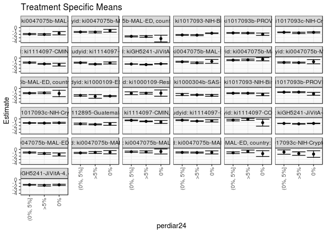

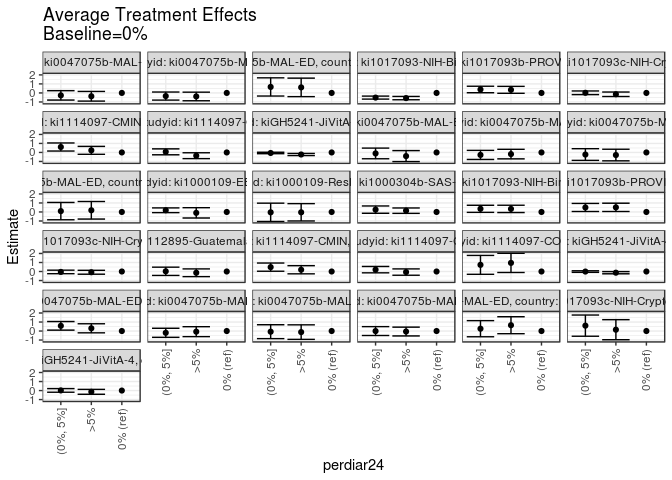

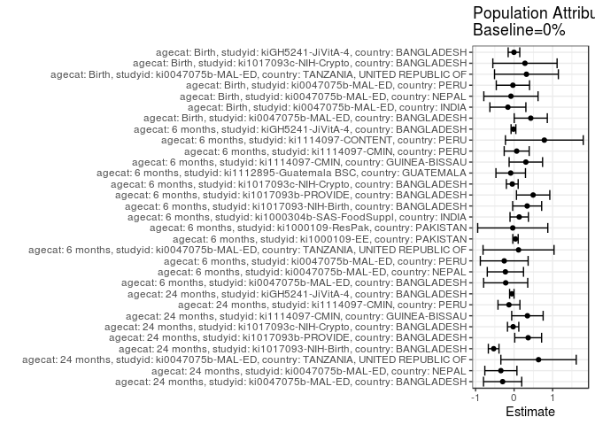

## Results Table

### Parameter: TSM

| agecat | studyid | country | intervention_level | baseline_level | estimate | ci_lower | ci_upper |
| --- | --- | --- | --- | --- | --- | --- | --- |
| Birth | ki0047075b-MAL-ED | BANGLADESH | 0% | NA | -1.5163636 | -1.9676423 | -1.0650849 |
| Birth | ki0047075b-MAL-ED | BANGLADESH | (0%, 5%] | NA | -0.9402055 | -1.0968826 | -0.7835283 |
| Birth | ki0047075b-MAL-ED | BANGLADESH | >5% | NA | -1.2141573 | -1.4355170 | -0.9927976 |
| Birth | ki0047075b-MAL-ED | INDIA | 0% | NA | -0.8491667 | -1.3234105 | -0.3749228 |
| Birth | ki0047075b-MAL-ED | INDIA | (0%, 5%] | NA | -1.0451923 | -1.2116817 | -0.8787029 |
| Birth | ki0047075b-MAL-ED | INDIA | >5% | NA | -0.9197368 | -1.2008730 | -0.6386007 |
| Birth | ki0047075b-MAL-ED | NEPAL | 0% | NA | -0.6264286 | -1.3758367 | 0.1229796 |
| Birth | ki0047075b-MAL-ED | NEPAL | (0%, 5%] | NA | -0.7001942 | -0.8832531 | -0.5171352 |
| Birth | ki0047075b-MAL-ED | NEPAL | >5% | NA | -0.7455357 | -1.0382343 | -0.4528372 |
| Birth | ki0047075b-MAL-ED | PERU | 0% | NA | -0.9007407 | -1.3627356 | -0.4387459 |
| Birth | ki0047075b-MAL-ED | PERU | (0%, 5%] | NA | -0.9054128 | -1.0770428 | -0.7337829 |
| Birth | ki0047075b-MAL-ED | PERU | >5% | NA | -0.9572185 | -1.1142403 | -0.8001968 |
| Birth | ki0047075b-MAL-ED | TANZANIA, UNITED REPUBLIC OF | 0% | NA | -1.2537500 | -2.1121999 | -0.3953001 |
| Birth | ki0047075b-MAL-ED | TANZANIA, UNITED REPUBLIC OF | (0%, 5%] | NA | -0.9958889 | -1.2515539 | -0.7402239 |
| Birth | ki0047075b-MAL-ED | TANZANIA, UNITED REPUBLIC OF | >5% | NA | -0.6080000 | -0.9936631 | -0.2223369 |
| Birth | ki1017093c-NIH-Crypto | BANGLADESH | 0% | NA | -1.3916667 | -2.3744611 | -0.4088722 |
| Birth | ki1017093c-NIH-Crypto | BANGLADESH | (0%, 5%] | NA | -0.7940000 | -1.4367037 | -0.1512963 |
| Birth | ki1017093c-NIH-Crypto | BANGLADESH | >5% | NA | -1.2436364 | -1.7669142 | -0.7203586 |
| Birth | kiGH5241-JiVitA-4 | BANGLADESH | 0% | NA | -1.4937949 | -1.6688487 | -1.3187410 |
| Birth | kiGH5241-JiVitA-4 | BANGLADESH | (0%, 5%] | NA | -1.4789945 | -1.5833701 | -1.3746189 |
| Birth | kiGH5241-JiVitA-4 | BANGLADESH | >5% | NA | -1.6347500 | -1.8434915 | -1.4260085 |
| 6 months | ki0047075b-MAL-ED | BANGLADESH | 0% | NA | -0.9866667 | -1.5612360 | -0.4120973 |
| 6 months | ki0047075b-MAL-ED | BANGLADESH | (0%, 5%] | NA | -1.0936150 | -1.2373445 | -0.9498855 |
| 6 months | ki0047075b-MAL-ED | BANGLADESH | >5% | NA | -1.3909140 | -1.5928426 | -1.1889854 |
| 6 months | ki0047075b-MAL-ED | NEPAL | 0% | NA | -0.3346429 | -0.8209957 | 0.1517099 |
| 6 months | ki0047075b-MAL-ED | NEPAL | (0%, 5%] | NA | -0.6079021 | -0.7446403 | -0.4711639 |
| 6 months | ki0047075b-MAL-ED | NEPAL | >5% | NA | -0.5163924 | -0.7261236 | -0.3066613 |
| 6 months | ki0047075b-MAL-ED | PERU | 0% | NA | -1.0700000 | -1.6970711 | -0.4429289 |
| 6 months | ki0047075b-MAL-ED | PERU | (0%, 5%] | NA | -1.3017584 | -1.4646943 | -1.1388225 |
| 6 months | ki0047075b-MAL-ED | PERU | >5% | NA | -1.3556369 | -1.5032709 | -1.2080030 |

[output cut: 63 more lines]

### Parameter: E(Y)

| agecat | studyid | country | intervention_level | baseline_level | estimate | ci_lower | ci_upper |
| --- | --- | --- | --- | --- | --- | --- | --- |
| Birth | ki0047075b-MAL-ED | BANGLADESH | NA | NA | -1.0843969 | -1.2100768 | -0.9587169 |
| Birth | ki0047075b-MAL-ED | INDIA | NA | NA | -1.0106311 | -1.1499962 | -0.8712660 |
| Birth | ki0047075b-MAL-ED | NEPAL | NA | NA | -0.7089017 | -0.8656064 | -0.5521971 |
| Birth | ki0047075b-MAL-ED | PERU | NA | NA | -0.9322300 | -1.0461262 | -0.8183337 |
| Birth | ki0047075b-MAL-ED | TANZANIA, UNITED REPUBLIC OF | NA | NA | -0.9338211 | -1.1465079 | -0.7211344 |
| Birth | ki1017093c-NIH-Crypto | BANGLADESH | NA | NA | -1.1100000 | -1.5086894 | -0.7113106 |
| Birth | kiGH5241-JiVitA-4 | BANGLADESH | NA | NA | -1.4976642 | -1.5817349 | -1.4135935 |
| 6 months | ki0047075b-MAL-ED | BANGLADESH | NA | NA | -1.2056777 | -1.3231497 | -1.0882058 |
| 6 months | ki0047075b-MAL-ED | NEPAL | NA | NA | -0.5610593 | -0.6737915 | -0.4483272 |
| 6 months | ki0047075b-MAL-ED | PERU | NA | NA | -1.3268010 | -1.4351217 | -1.2184802 |
| 6 months | ki0047075b-MAL-ED | TANZANIA, UNITED REPUBLIC OF | NA | NA | -1.3601215 | -1.4821830 | -1.2380600 |
| 6 months | ki1000109-EE | PAKISTAN | NA | NA | -2.2004704 | -2.3234073 | -2.0775336 |
| 6 months | ki1000109-ResPak | PAKISTAN | NA | NA | -1.4029220 | -1.6085859 | -1.1972581 |
| 6 months | ki1000304b-SAS-FoodSuppl | INDIA | NA | NA | -1.8986842 | -2.0118892 | -1.7854792 |
| 6 months | ki1017093-NIH-Birth | BANGLADESH | NA | NA | -1.4073821 | -1.4960598 | -1.3187043 |
| 6 months | ki1017093b-PROVIDE | BANGLADESH | NA | NA | -1.0871041 | -1.1635539 | -1.0106543 |
| 6 months | ki1017093c-NIH-Crypto | BANGLADESH | NA | NA | -1.1986783 | -1.2700937 | -1.1272630 |
| 6 months | ki1112895-Guatemala BSC | GUATEMALA | NA | NA | -1.5619008 | -1.6727702 | -1.4510313 |
| 6 months | ki1114097-CMIN | GUINEA-BISSAU | NA | NA | -0.6003317 | -0.6767125 | -0.5239510 |
| 6 months | ki1114097-CMIN | PERU | NA | NA | -0.5132548 | -0.5926717 | -0.4338380 |
| 6 months | ki1114097-CONTENT | PERU | NA | NA | -0.3139217 | -0.4868486 | -0.1409948 |
| 6 months | kiGH5241-JiVitA-4 | BANGLADESH | NA | NA | -1.3447940 | -1.3820261 | -1.3075620 |
| 24 months | ki0047075b-MAL-ED | BANGLADESH | NA | NA | -1.9431132 | -2.0691678 | -1.8170586 |
| 24 months | ki0047075b-MAL-ED | NEPAL | NA | NA | -1.2752193 | -1.3954783 | -1.1549603 |
| 24 months | ki0047075b-MAL-ED | TANZANIA, UNITED REPUBLIC OF | NA | NA | -2.6058879 | -2.7403043 | -2.4714714 |
| 24 months | ki1017093-NIH-Birth | BANGLADESH | NA | NA | -2.1807945 | -2.2835902 | -2.0779987 |
| 24 months | ki1017093b-PROVIDE | BANGLADESH | NA | NA | -1.5861179 | -1.6693668 | -1.5028689 |
| 24 months | ki1017093c-NIH-Crypto | BANGLADESH | NA | NA | -1.4295331 | -1.5127726 | -1.3462935 |
| 24 months | ki1114097-CMIN | GUINEA-BISSAU | NA | NA | -1.5996561 | -1.6995642 | -1.4997481 |
| 24 months | ki1114097-CMIN | PERU | NA | NA | -1.5759624 | -1.6729826 | -1.4789423 |
| 24 months | kiGH5241-JiVitA-4 | BANGLADESH | NA | NA | -1.7582681 | -1.7937283 | -1.7228079 |

### Parameter: ATE

| agecat | studyid | country | intervention_level | baseline_level | estimate | ci_lower | ci_upper |
| --- | --- | --- | --- | --- | --- | --- | --- |
| Birth | ki0047075b-MAL-ED | BANGLADESH | 0% | 0% | 0.0000000 | 0.0000000 | 0.0000000 |
| Birth | ki0047075b-MAL-ED | BANGLADESH | (0%, 5%] | 0% | 0.5761582 | 0.0984551 | 1.0538612 |
| Birth | ki0047075b-MAL-ED | BANGLADESH | >5% | 0% | 0.3022063 | -0.2004393 | 0.8048519 |
| Birth | ki0047075b-MAL-ED | INDIA | 0% | 0% | 0.0000000 | 0.0000000 | 0.0000000 |
| Birth | ki0047075b-MAL-ED | INDIA | (0%, 5%] | 0% | -0.1960256 | -0.6986447 | 0.3065934 |
| Birth | ki0047075b-MAL-ED | INDIA | >5% | 0% | -0.0705702 | -0.6218820 | 0.4807417 |
| Birth | ki0047075b-MAL-ED | NEPAL | 0% | 0% | 0.0000000 | 0.0000000 | 0.0000000 |
| Birth | ki0047075b-MAL-ED | NEPAL | (0%, 5%] | 0% | -0.0737656 | -0.8452079 | 0.6976767 |
| Birth | ki0047075b-MAL-ED | NEPAL | >5% | 0% | -0.1191071 | -0.9236474 | 0.6854331 |
| Birth | ki0047075b-MAL-ED | PERU | 0% | 0% | 0.0000000 | 0.0000000 | 0.0000000 |
| Birth | ki0047075b-MAL-ED | PERU | (0%, 5%] | 0% | -0.0046721 | -0.4975170 | 0.4881728 |
| Birth | ki0047075b-MAL-ED | PERU | >5% | 0% | -0.0564778 | -0.5444276 | 0.4314720 |
| Birth | ki0047075b-MAL-ED | TANZANIA, UNITED REPUBLIC OF | 0% | 0% | 0.0000000 | 0.0000000 | 0.0000000 |
| Birth | ki0047075b-MAL-ED | TANZANIA, UNITED REPUBLIC OF | (0%, 5%] | 0% | 0.2578611 | -0.6378513 | 1.1535736 |
| Birth | ki0047075b-MAL-ED | TANZANIA, UNITED REPUBLIC OF | >5% | 0% | 0.6457500 | -0.2953516 | 1.5868516 |
| Birth | ki1017093c-NIH-Crypto | BANGLADESH | 0% | 0% | 0.0000000 | 0.0000000 | 0.0000000 |
| Birth | ki1017093c-NIH-Crypto | BANGLADESH | (0%, 5%] | 0% | 0.5976667 | -0.5766216 | 1.7719550 |
| Birth | ki1017093c-NIH-Crypto | BANGLADESH | >5% | 0% | 0.1480303 | -0.9653899 | 1.2614505 |
| Birth | kiGH5241-JiVitA-4 | BANGLADESH | 0% | 0% | 0.0000000 | 0.0000000 | 0.0000000 |
| Birth | kiGH5241-JiVitA-4 | BANGLADESH | (0%, 5%] | 0% | 0.0148004 | -0.1873123 | 0.2169130 |
| Birth | kiGH5241-JiVitA-4 | BANGLADESH | >5% | 0% | -0.1409551 | -0.4123675 | 0.1304572 |
| 6 months | ki0047075b-MAL-ED | BANGLADESH | 0% | 0% | 0.0000000 | 0.0000000 | 0.0000000 |
| 6 months | ki0047075b-MAL-ED | BANGLADESH | (0%, 5%] | 0% | -0.1069484 | -0.6992220 | 0.4853253 |
| 6 months | ki0047075b-MAL-ED | BANGLADESH | >5% | 0% | -0.4042473 | -1.0132671 | 0.2047724 |
| 6 months | ki0047075b-MAL-ED | NEPAL | 0% | 0% | 0.0000000 | 0.0000000 | 0.0000000 |
| 6 months | ki0047075b-MAL-ED | NEPAL | (0%, 5%] | 0% | -0.2732592 | -0.7784685 | 0.2319500 |
| 6 months | ki0047075b-MAL-ED | NEPAL | >5% | 0% | -0.1817495 | -0.7113968 | 0.3478977 |
| 6 months | ki0047075b-MAL-ED | PERU | 0% | 0% | 0.0000000 | 0.0000000 | 0.0000000 |
| 6 months | ki0047075b-MAL-ED | PERU | (0%, 5%] | 0% | -0.2317584 | -0.8796522 | 0.4161353 |
| 6 months | ki0047075b-MAL-ED | PERU | >5% | 0% | -0.2856369 | -0.9298527 | 0.3585789 |

[output cut: 63 more lines]

### Parameter: PAR

| agecat | studyid | country | intervention_level | baseline_level | estimate | ci_lower | ci_upper |
| --- | --- | --- | --- | --- | --- | --- | --- |
| Birth | ki0047075b-MAL-ED | BANGLADESH | 0% | NA | 0.4319667 | 0.0023374 | 0.8615961 |
| Birth | ki0047075b-MAL-ED | INDIA | 0% | NA | -0.1614644 | -0.6285052 | 0.3055764 |
| Birth | ki0047075b-MAL-ED | NEPAL | 0% | NA | -0.0824732 | -0.7862289 | 0.6212825 |
| Birth | ki0047075b-MAL-ED | PERU | 0% | NA | -0.0314892 | -0.4630588 | 0.4000803 |
| Birth | ki0047075b-MAL-ED | TANZANIA, UNITED REPUBLIC OF | 0% | NA | 0.3199289 | -0.5085096 | 1.1483673 |
| Birth | ki1017093c-NIH-Crypto | BANGLADESH | 0% | NA | 0.2816667 | -0.5523333 | 1.1156666 |
| Birth | kiGH5241-JiVitA-4 | BANGLADESH | 0% | NA | -0.0038694 | -0.1544342 | 0.1466955 |
| 6 months | ki0047075b-MAL-ED | BANGLADESH | 0% | NA | -0.2190111 | -0.7912200 | 0.3531979 |
| 6 months | ki0047075b-MAL-ED | NEPAL | 0% | NA | -0.2264165 | -0.6967181 | 0.2438852 |
| 6 months | ki0047075b-MAL-ED | PERU | 0% | NA | -0.2568010 | -0.8771126 | 0.3635107 |
| 6 months | ki0047075b-MAL-ED | TANZANIA, UNITED REPUBLIC OF | 0% | NA | 0.1148785 | -0.8064024 | 1.0361595 |
| 6 months | ki1000109-EE | PAKISTAN | 0% | NA | 0.0357657 | -0.0338547 | 0.1053861 |
| 6 months | ki1000109-ResPak | PAKISTAN | 0% | NA | -0.0356493 | -0.9456233 | 0.8743248 |
| 6 months | ki1000304b-SAS-FoodSuppl | INDIA | 0% | NA | 0.1324117 | -0.1060466 | 0.3708700 |
| 6 months | ki1017093-NIH-Birth | BANGLADESH | 0% | NA | 0.3386179 | -0.0376278 | 0.7148637 |
| 6 months | ki1017093b-PROVIDE | BANGLADESH | 0% | NA | 0.4937293 | 0.0614510 | 0.9260076 |
| 6 months | ki1017093c-NIH-Crypto | BANGLADESH | 0% | NA | -0.0478574 | -0.2008955 | 0.1051807 |
| 6 months | ki1112895-Guatemala BSC | GUATEMALA | 0% | NA | -0.0882226 | -0.4715980 | 0.2951527 |
| 6 months | ki1114097-CMIN | GUINEA-BISSAU | 0% | NA | 0.3046683 | -0.1294161 | 0.7387526 |
| 6 months | ki1114097-CMIN | PERU | 0% | NA | 0.0667452 | -0.2576723 | 0.3911626 |
| 6 months | ki1114097-CONTENT | PERU | 0% | NA | 0.7844950 | -0.2254843 | 1.7944743 |
| 6 months | kiGH5241-JiVitA-4 | BANGLADESH | 0% | NA | -0.0168616 | -0.0788403 | 0.0451171 |
| 24 months | ki0047075b-MAL-ED | BANGLADESH | 0% | NA | -0.2981132 | -0.7939931 | 0.1977667 |
| 24 months | ki0047075b-MAL-ED | NEPAL | 0% | NA | -0.3435526 | -0.7600203 | 0.0729150 |
| 24 months | ki0047075b-MAL-ED | TANZANIA, UNITED REPUBLIC OF | 0% | NA | 0.6341121 | -0.3439520 | 1.6121763 |
| 24 months | ki1017093-NIH-Birth | BANGLADESH | 0% | NA | -0.5307945 | -0.6692585 | -0.3923305 |
| 24 months | ki1017093b-PROVIDE | BANGLADESH | 0% | NA | 0.3649933 | 0.0164680 | 0.7135185 |
| 24 months | ki1017093c-NIH-Crypto | BANGLADESH | 0% | NA | -0.0253054 | -0.1719577 | 0.1213469 |
| 24 months | ki1114097-CMIN | GUINEA-BISSAU | 0% | NA | 0.3455105 | -0.0624383 | 0.7534594 |
| 24 months | ki1114097-CMIN | PERU | 0% | NA | -0.1339010 | -0.4183107 | 0.1505086 |
| 24 months | kiGH5241-JiVitA-4 | BANGLADESH | 0% | NA | -0.0594737 | -0.1169742 | -0.0019732 |